# Aides Tests

Jerron Davison

May 24, 2017

# Instructions

Three new preventative aides drugs were tested in clinical trials in 2015. The trial designs were modeled after the famous RV_144 Aides Trials in Tailand in 2009. Analyze and report on the apparent effectiveness of the three different drugs. Does sex of the participant seem to be a factor for any of the drugs?

# Genvoyabub

# Atriplavast

# abacavirinol

We will subset the data by sex to see if the drug is sex specific.

Let us review the numerical results

```r
Abaca <- xtabs (~infected +group, data=abacavirinol)
Abaca
```

```
##         group
## infected drug placebo
##     aids  118     121
##     none 2082    2079
```

For group who was infected with AIDS, there were 118 who took Abacavirinol, and 121 who took the placebo.

For group who was infected with None, there were 2082 who took Abacavirinol, and 2079 who took the placebo.

Lets take a further look into the data.

## Infected vs. Group Two-way table:

```r
rowPerc(Abaca)
```

```
##         group
## infected   drug placebo  Total
##     aids  49.37   50.63 100.00
##     none  50.04   49.96 100.00
```

For the people who were infected with AIDS, 49.37% took Abacavirinol, and 50.63% took the placebo.

For the people who were infected with None, 50.04% took Abacavirinol and 49.96% took the placebo.

After reviewing the numerical data, people who were infected group with AIDS who took Abacavirinol had almost the similar infection rate than those who took the placebo. The group who was not infected did not show much of a difference either.

Lets look at the groups

## Group vs. Infected Two-way table:

```r
colPerc(Abaca)
```

```
##         group
## infected   drug placebo
##    aids    5.36     5.5
##    none   94.64    94.5
##    Total 100.00   100.0
```

After reviewing the numerical data, people who took Abacavirinol had a similar AIDS infection rate than those who took the placebo. The group who was not infected did not show much of a difference either.

Now that we have reviewed the numerical data, we will construct a bar chart to examine the graphical results of the data.

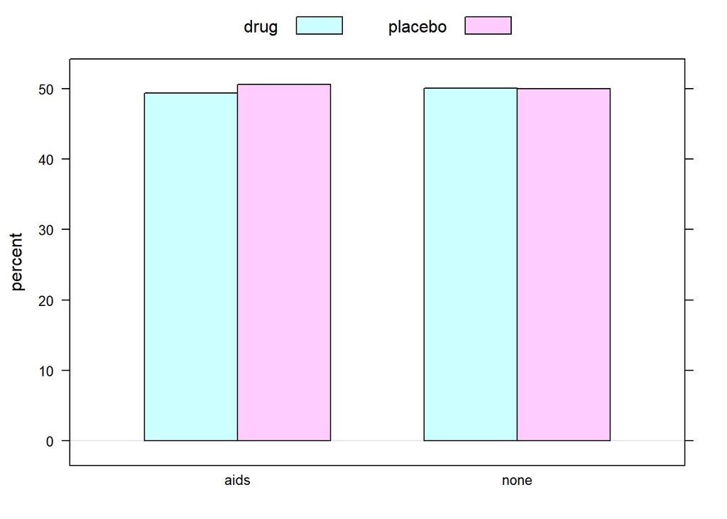

```r
barchartGC (Abaca, type="percent")
```

After inputing the data into a barchart, it appears that the groups who were infected with AIDS have a simimar ocuurence rate of the virus. The group who did not get infected shows no difference.

Now that we have graphically viewed that data, we will run an inferrential test to test their relationship

Let us begin by forming our two hypotheses:

$H_0:$ Getting the AIDS virus is independent of taking Abacavirinol. $H_A:$ Getting the AIDS virus is dependent of taking Abacavirinol.

```r
chisqtestGC(Abaca)
```

```
## Pearson's Chi-squared test with Yates' continuity correction
##
## Observed Counts:
##         group
## infected drug placebo
##     aids  118     121
##     none 2082    2079
##
## Counts Expected by Null:
##         group
## infected   drug placebo
##     aids  119.5   119.5
##     none 2080.5  2080.5
##
## Contributions to the chi-square statistic:
##         group
## infected drug placebo
##     aids 0.02    0.02
##     none 0.00    0.00
##
##
## Chi-Square Statistic = 0.0177
## Degrees of Freedom of the table = 1
## P-Value = 0.8942
```

## Conclusion

From the three tests we ran on the data for AIDS and Abacavirinol, we have seen that there is not a relationship between the drug and getting the virus. We saw the evidence outlined in the numerical test, barchart, and chi squared test. They showed us that people who take Abacavirinol had a slightly equal occurrence of AIDS than those who took the placebo. From these tests we can conclude that, Abacavirinol does not work effectivley to treat the AIDS virus.

Now, we will subset the data by sex to see if the drug is sex specific.

Now for the Femaeles

Abacavirinol Females Let us review the numerical results

```r
BF<- filter(abacavirinol, sex=="F")
BF2<- xtabs (~infected +group, data=BF)
BF2
```

```
##         group
## infected drug placebo
##     aids   40      63
##     none 1060    1037
```

## Infected vs. Group Two-way table:

```r
rowPerc(BF2)
```

```
##         group
## infected   drug placebo  Total
##     aids  38.83   61.17 100.00
##     none  50.55   49.45 100.00
```

For the females who were infected with AIDS, 38.83% took Abacavirinol, and 61.17% took the placebo.

For the females who were infected with None, 50.55% took Abacavirinol and 49.45% took the placebo.

After reviewing the numerical data, women in the AIDS infected group, who took Abacavirinol had a noticeably lower infection rate than those who took the placebo. The group who was not infected did not show much of a difference.

## Group vs. Infected Two-way table:

```r
colPerc(BF2)
```

```
##         group
## infected   drug placebo
##    aids    3.64    5.73
##    none   96.36   94.27
##    Total 100.00  100.00
```

For the females who took the placebo, 5.73% recieved AIDS, and 94.27% recieved none.

After reviewing the numerical data, females who took Abacavirinol had a lower rate of AIDS infection than those who took the placebo. The difference is also reflected right under with the groups who was not infected.

Now that we have reviewed the numerical data for women, we will construct a bar chart to examine the graphical results of the data.

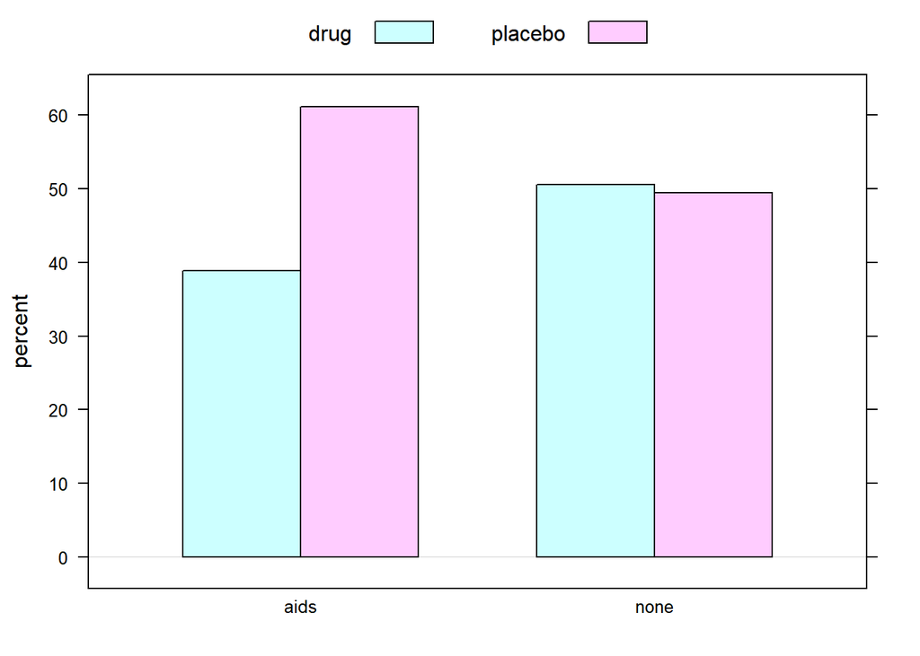

```r
barchartGC (BF2, type="percent")
```

After inputing the data into a barchart, it appears that the female groups who were infected with AIDS have a large difference in the ocuurence. The females who took Abacavirinol recieved the virus at a noticeably lower rate than those who took the placebo. The group who did not shows no difference.

Now that we have graphically viewed that data, we will run an inferrential test to test their relationship

Let us begin by forming our two hypotheses:

$H_0:$ For women, getting the AIDS virus is independent of taking Abacavirinol. $H_A:$ For women, getting the AIDS virus is dependent of taking Abacavirinol.

```r
chisqtestGC(BF2)
```

```
## Pearson's Chi-squared test with Yates' continuity correction
##
## Observed Counts:
##         group
## infected drug placebo
##     aids   40      63
##     none 1060    1037
##
## Counts Expected by Null:
##         group
## infected   drug placebo
##     aids   51.5    51.5
##     none 1048.5  1048.5
##
## Contributions to the chi-square statistic:
##         group
## infected drug placebo
##     aids 2.57    2.57
##     none 0.13    0.13
##
##
## Chi-Square Statistic = 4.9298
## Degrees of Freedom of the table = 1
## P-Value = 0.0264
```

## Conclusion

From the three tests we ran on the data from females, we have seen that there is a relationship between the drug and the rate of infection. We saw the evidence outlined in the numerical test, barchart, and chi squared test. The barchart and numerical tests shows us that women who take Abacavirinol had a lower occurrence of AIDS. Our chi squared test showed us, for women, there is a relationship between getting the AIDS virus is and taking Abacavirinol.. From these tests we can conclude that, Women who take Abacavirinol reduce their probablity of getting the AIDS virus. This shows us that Abacavirinol works well for treating AIDS, in women.

Now for the men

Abacavirinol males Let us review the numerical results

```r
BM<- filter (abacavirinol, sex=="M")
BM2<- xtabs (~infected +group, data=BM)
BM2
```

```
##         group
## infected drug placebo
##     aids   78      58
##     none 1022    1042
```

For group of males who were infected with AIDS, there were 78 who took Abacavirinol, and 58 who took the placebo.

For group of males who was infected with None, there were 1022 who took Abacavirinol, and 1042 who took the placebo.

## Infected vs. Group Two-way table:

```r
rowPerc(BM2)
```

```
##         group
## infected   drug placebo  Total
##     aids  57.35   42.65 100.00
##     none  49.52   50.48 100.00
```

For the males who were infected with AIDS, 57.35% took Abacavirinol, and 42.65% took the placebo.

After reviewing the numerical data, men in the AIDS infected group, who took Abacavirinol had a slightly higher infection rate than those in the group who took the placebo. The men who were not infected did not show much of a difference.

## Group vs. Infected Two-way table:

```r
colPerc(BM2)
```

```
##         group
## infected   drug placebo
##    aids    7.09    5.27
##    none   92.91   94.73
##    Total 100.00  100.00
```

For the males who took Abacavirinol, 7.09% recieved AIDS, and 92.91% recieved none.

For the males who took the placebo, 5.27% recieved AIDS, and 94.73% recieved none.

After reviewing the numerical data, males who took Abacavirinol had a higher rate of AIDS infection than those who took the placebo. The difference is also reflected right under with the groups who were not infected.

Now that we have reviewed the numerical data for men, we will construct a bar chart to examine the graphical results of the data.

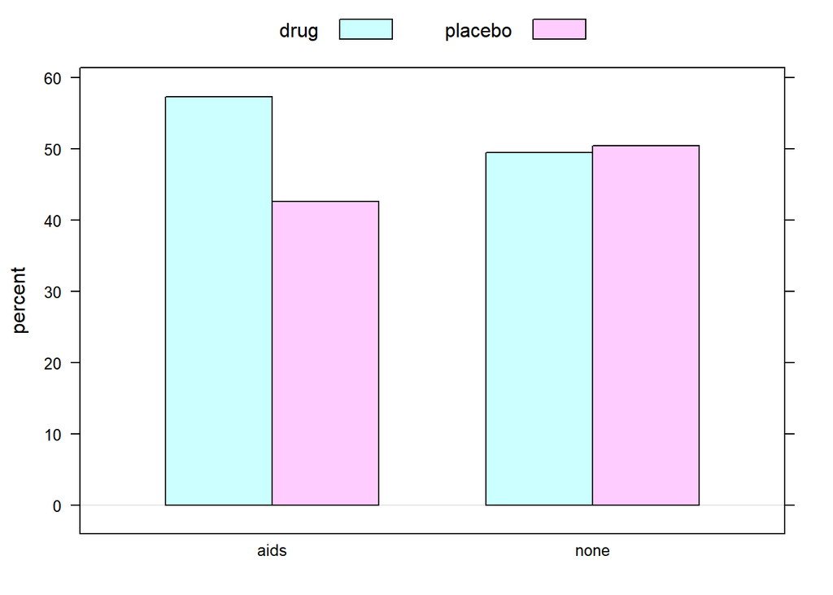

```r
barchartGC (BM2, type="percent")
```

After inputing the data into a barchart, it appears that the male groups who were infected with the AIDS virus have a noticeable difference in the ocuurence. The males who took Abacavirinol recieved the virus at a higher rate than those who took the placebo. The group who did not shows no difference.

Let us begin by forming our two hypotheses:

$H_0:$ For men, getting the AIDS virus is independent of taking Abacavirinol. $H_A:$ For men, getting the AIDS virus is dependent of taking Abacavirinol.

```r
chisqtestGC(BM2)
```

```
## Pearson's Chi-squared test with Yates' continuity correction
##
## Observed Counts:
##         group
## infected drug placebo
##     aids   78      58
##     none 1022    1042
##
## Counts Expected by Null:
##         group
## infected drug placebo
##     aids   68      68
##     none 1032    1032
##
## Contributions to the chi-square statistic:
##         group
## infected drug placebo
##     aids 1.47    1.47
##     none 0.10    0.10
##
##
## Chi-Square Statistic = 2.8293
## Degrees of Freedom of the table = 1
## P-Value = 0.0926
```